# 1 Introduction to soils

## 1.1 Definition

A granular material is a collection of particles such that each particle is in contact with several of its neighbor. Soil is a granular material; variety of minerals form the soil particles, which result from [weathering](https://en.wikipedia.org/wiki/Weathering) of the rock: physical weathering–mechanical processes such as temperature fluctuation, abrasion; chemical weathering–chemical interaction of air and water with fissured rock; biological weathering–breakdown because of burrowing animals, plan roots. Fluids–air, water, or some other fluids–are present in the pore spaces.

**Readings**: [Principle of rock weathering](https://www.journals.uchicago.edu/doi/pdf/10.1086/607624), [Clays and weathering cycles](https://doi.org/10.1038/121903a0)

## 1.2 [Classification](https://doi.org/10.1061/TACEAT.0006109)

The soil particle size ranges from 1$\mu{m}$ to 1$m$. We name the soils on the basis of their particle sizes, as it correlates with the soil behavior. Colloidal mixtures have roughly the clay size particles which explain some of the behavior of clays.

Table 1: Different types of soils

| Soil | Size range |
| --- | --- |
| Clay* | < 5$\mu{m}$ |
| Silt* | 5$\mu{m}$–75$\mu{m}$ |
| Sand# | 75$\mu{m}$–4.75$mm$ |
| Gravels# | 4.75$mm$–75$mm$ |
| Boulders# | > 300$mm$ |

[*] - Hydrometer test (based on Stokes’ law) [#] - Sieve analysis

### 1.2.1 [Hydrometer test](https://www.astm.org/Standards/D7928.htm)

The first article in [hydrometer test](https://doi.org/10.1097/00010694-192705000-00002)

**We can also use laser techniques, such as Mastersizer, in place of** **hydrometer.**

### 1.2.2 [Sieve analysis](https://www.astm.org/DATABASE.CART/HISTORICAL/D6913-04.htm)

**Readings**: [Laser method](https://doi.org/10.1046/j.1365-3091.1997.d01-38.x) [Sample size and sieve](https://doi.org/10.1002/jctb.5000650902)

### 1.2.3 Grain size distribution

The soil behavior is a function of grain size distribution; grain size distribution is often present as a probability distribution function (cumulative):

$$\begin{align}
P\left(X \leq D\right) = P\{x \leq D \forall x \in \omega\}
\end{align}$$

Where $X$ is the random variable corresponding to soil particle size.

We use coefficient of uniformity ($C_{U}$) and coefficient of curvature ($C_{C}$) to compare the grain size distributions.

$$\begin{align}
C_{U} = \dfrac{D_{60}}{D_{10}} \\
C_{C} = \dfrac{\left(D_{30}\right)^{2}}{D_{10}D_{60}}
\end{align}$$

For a well graded soil: $C_{U}\geq{4}$ and $C_{C}\in\left[1, 3\right]$. For a poorly graded soil: $C_{U}\leq{2}$.

**Note**: The structure and morphology of the soil is independent of the grain size distribution.

**Readings**: [Grading with the wind](https://doi.org/10.1098/rspa.1937.0225)

### 1.2.4 Plasticity

Plasticity is the ability of the soil to deform without crumbling when mixed with water. Plasticity is quantified with the *Atterberg consistency limit* test using plasticity indices–shrinkage limit (SL), plastic limit (PL), and liquid limit (LL). Plasticity index (PI) is defined as:

$$\begin{align}
PI = LL-PL
\end{align}$$

**Readings** [History of consistency limits](https://www.astm.org/DIGITAL_LIBRARY/STP/PAGES/STP44312S.htm) [Clay plasticity](https://doi.org/10.1016/j.clay.2010.10.028)

### 1.2.5 Soil classification system

We classify soils according to grain size distributions and plasticity indices.

Symbols used to classify the soils.

Table 2: Soil classifiers

| G | S | M | C | O | W | P | L | H |
| --- | --- | --- | --- | --- | --- | --- | --- | --- |
| Gravel | Sand | Silt | Clay | Organic | Well graded | Poorly graded | LL<50% | LL>50% |

**Reading** [USCS](https://dot.ca.gov/-/media/dot-media/programs/maintenance/documents/office-of-concrete-pavement/pavement-foundations/uscs-a11y.pdf)

## 1.3 Composition of soil particles

- A mineral is an organic compound mostly with crystalline structure:
  - One or more minerals compose soil particles:
    - Soil minerals are:
      1. Silicates:
      - [quartz](https://en.wikipedia.org/wiki/Quartz),
      - [feldspar](https://en.wikipedia.org/wiki/Feldspar),
      - [mica](https://en.wikipedia.org/wiki/Mica),
      - [clay minerals](https://en.wikipedia.org/wiki/Clay_mineral)
      2. Carbonates
      3. Oxides–iron and aluminium oxides
      4. Sulphate
      5. Gypsum

Carbonates are found in **residual soils of carbonate rocks** (limestone and dolomite). Iron and aluminium oxides are present in the tropical soil. Iron oxide causes reddish color of soil. Sulphate and gypsum occur in arid regions.

## 1.4 Effective stress principle

We are interested in the hydo-mechanical properties of soils for design problems. The hydraulic properties are related with the transport of fluid in the pore spaces, whereas the mechanical properties are related with the stiffness and strength of the soil (soil skeleton, precisely). The stiffness and strength of soil derive from the interaction of particles:

1. Elastic deformation at contacts. [elastic]
2. Bending of elongated particles. [elastic]
3. Particle crushing at contacts. [inelastic]
4. Particle breakage. [inelastic]
5. Particle sliding or rolling. [inelastic]

elastic deformation–energy stored (Elastic strains–$10^{-5}$.) inelastic deformation–energy dissipated

The crushing at particle contacts and breakage occur at relatively high pressure. These would not be consider for this discussion. Any inelastic deformation would result from the pore collapse or expansion due to sliding or rolling of particles at the contacts. The contact law and the imposed contact stresses are responsible for deformation at the contacts. To avoid the contact law (unknown), Terzaghi introduced effective stress as a representative of fraction of total stress at the contact. The effective stress principle states

> The total force acting on area A of soil is partly supported by the soil skeleton (through contacts between soil particles) and partly by the pore fluid.

We write effective stress principle as
$$\begin{aligned}
\texttt{Total force} &= \texttt{Force on the soil skeleton} + \texttt{Force on the
pore fluid}\\
\texttt{Total stress} &= \texttt{Stress on soil skeleton} + \texttt{Pore pressure}\\
\sigma_{ij} &= \sigma_{ij}^{'} + u\delta_{ij}
\end{aligned}$$

**Effective stress is different from the contact stress**: it is related with the force on the soil skeleton.

If we apply $d\sigma_{ij}$ on a saturated soil with undrained condition (no volume change), pore fluid carries the additional stress but not the soil skeleton. We can show this by the following:

$$\begin{aligned}
d\sigma_{ij} &= d\sigma_{ij}^{'} + du\delta_{ij} \\
d\sigma_{ij}^{'} &= \mathscr{C}_{ijkl}^{'} d\epsilon_{kl} \\
du &= K_{f}d\epsilon_{f} \\
d\sigma_{ij} &= \mathscr{C}_{ijkl}^{'} d\epsilon_{kl}
+ \dfrac{\mathscr{K}_{f}}{\eta_{f}} d\epsilon_{kk} \delta_{ij} \\
ds_{ij} &= \mathscr{C}_{ijkl}^{'}de_{kl} \\
dp^{'} &= \dfrac{1}{9}\mathscr{C}_{jjkk}^{'}d\epsilon_{pp}
\end{aligned}$$

Any additional stress is shared by the pore fluid and the soil skeleton; the pore fluid deformation is equal to the deformation of skeleton pores–we use same strain tensor for both pore fluid and skeleton. It is inaccurate to say, “there is no volumetric deformation in undrained condition.”; however, the volumetric deformation is significantly small. For this significantly small volumetric strain due to increment in stress, the pore fluid pressure changes significantly and trace of the effective stress by a small amount, since:

$$\begin{aligned}
\mathscr{K_{f}} \ggg \mathscr{C}_{jjkk}^{'}
\end{aligned}$$

**Note that we can not say much about $ds_{ij}$ without more information.**

We allow excess pore fluid pressure to dissipate in drained condition. An accurate drained condition requires:

$$\begin{aligned}
t_{d} \ll t_{li}
\end{aligned}$$

Where $t_{d}$ is time require for dissipation (we can assume 90% degree of consolidation); $t_{li}$ is time require for load increment by a significant amount.

We cannot achieve a perfect drained condition since 100% consolidation is never achieved, and even to keep a high degree of consolidation the rate of loading has to be very small. In experiments, we always see significant excess pore fluid pressure in drained condition.

Further, we assume the saturated conditions which are partially assumed.

**Readings** [Effective stress in saturated and partially saturated soil](https://doi.org/10.1680/geot.1963.13.3.177)

### 1.4.1 Continuum modeling of soils

What do we mean by shear strength of the soil? Is it shear strength of 1 particle, 10 particles, 1000 particles, 1 billion particles? It is found that there should be sufficient number of particles (around 10 particles) to have a consistent soil property. If we have lesser number of particles, it will constitute a highly discontinuous field. With lesser number of particles we can not use the continuum theories and models, as the derivatives are not defined.

# 2 Genesis of soils and rocks

Geology is very important in understanding of the soils; behavior of soil is a function of it’s structure. The natural soil deposits have different structures depending on their origin.

> Earth is a giant recycling machine, constantly transforming soil into rock, solid rock into molten rock, molten rock into rock again, and rock into soil. Additionally material gets transported from one place to other fig. 1. – The engineering of foundations, Salgado R.

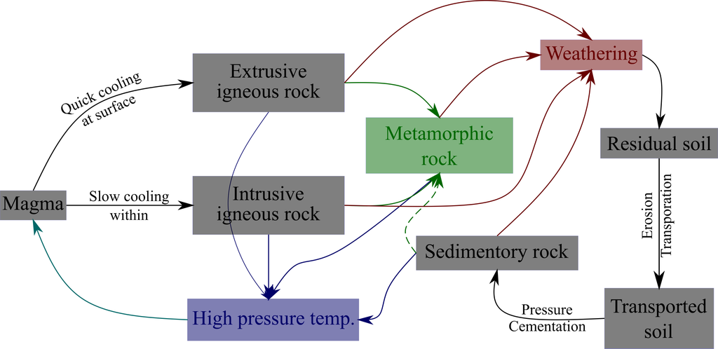

Figure 1: Genesis of rocks and soils

## 2.1 Rock genesis

### 2.1.1 Igneous rock

At the convergent boundaries, two tectonic plates collide and generate heat; high temperature and pressure magnifies the heat at greater depths. This excess heat melts rock into magma, migrates it upward, and creates volcano. Magma cools very fast on the surface, solidifies and generates magmatic rocks, called extrusive igneous rocks. In some cases, the magma does not reach the surface, and solidifies slowly within a cooler rock mass, called intrusive igneous rocks.

The cooling rate controls the appearance and properties of the rock. Large grains of minerals form due to grouping during hardening with slow cooling in intrusive rocks; we can identify mica, feldspar, and quartz in graphite. Minerals group together; bonds between same substances have lower potential energy. Minerals grouping slows down if the cooling is too fast; it gives a homogeneous appearance to extrusive rocks, such as basalt.

### 2.1.2 Sedimentary rock

Sedimentary rocks form due to compression and cementation between soil particles at larger depths. The pore water flows through these soils and deposits the cement at the particle contacts and voids. The soil goes through various forms in this process called diagenesis or lithification. Sedimentary rocks are named after the base particulate material.

Table 3: Particle base and sedimentary rocks

| Base | Sedimentary rock |
| --- | --- |
| Sands | Sandstones |
| Clays | Claystones |
| Silts | Siltstones |
| Clays and silts | Shales |
| Gravels | Conglomerate or breccias |

### 2.1.3 Metamorphic rock

Metamorphic rock forms when igneous, sedimentary, or other metamorphic rocks transform under great temperature and pressure. The high temperatures cause flow of rocks and with high pressure the mineral realign themselves along the direction of the pressure.

Table 4: Metamorphic rock source

| Parent rock | Metamorphic rock |
| --- | --- |
| Granite | Gneiss |
| Sandstone | Quartzite |
| Shale | Slate |
| Shale | Schist |
| Limestones | Marble |

## 2.2 Soil genesis

### 2.2.2 Transported soils

The residual soil erode and transport to other places by various agent to create soil deposits. The transported soils have different grain size distribution and fabric depending on the deposition process and transporting agent. We have the following as the transporting agents and corresponding soil.

Table 5: Transported soils

| Transporting agent | Soil name | Observations |
| --- | --- | --- |
| Wind | *Aeolian* | Uniform particle sizes |
| Water (streams and rivers) | *Alluvial* | Intermixed clay, silt, and sand layers |
| Water (lakes) | *Lacustrine* | layering due to seasonal factors |
| Water (ocean) | *Marine* | Possibly quick clay |
| Ice (glacier advance) | *Glacial soils* | Wide range of particle sizes |
| Gravity*(rolling on cliff) | *Colluvial* | Wide range of particle sizes |

- **Aeolian deposits**–Wind carries the soil particles of same size due to its carrying capacity; dune sand for example is quite uniform in gradation.
- **Alluvial deposits**–River stream carries particles of various sizes with it, deposits the particles depending on the velocity of stream which changes depended on the basin profile.

# 3 Textbook soils/Classic soils

Classic soils are clays and sands–residual soils; we have studied them extensively. Gravel and non-plastic silts–sands plastic silts–clays

## 3.1 Silica sand

Silica sand, mostly quartz particles, is found abundantly in the nature. It can be:

- fine sand
- medium coarse sand
- coarse sand

with shapes:

- Angular
- Sub-angular
- Sub-rounded
- Rounded

Angular particles mobilize higher strength due to the interlocking in comparison to the rounded particles.

## 3.2 Clays

**Composition of clays** clays are made up of clay mineral particles. These minerals form with the chemical weathering of rocks (feldspar, mica, and ferro-magnesian). Clays are the end product of weathering since they are resistant to weather. Clay minerals behave plastically in the presence of water due to net negative charge. Basic components of minerals:

- Silicon tetrahedron
- Aluminium or magnesian octahedron

In these, central cation ($Si^{+4}$, $Al^{+3}$, or $Mg^{+2}$) is surrounded by the oxygens or hydroxyls. These components form silica sheet with silica cation, alumina sheet (gibbsite sheet) with aluminium ion ($Al^{+3}$), and brucite sheet with magnesium ions ($Mg^{+2}$). The combination of these sheets form different clay minerals.

Table 6: Common clay minerals

| Clay minerals | Structure | Interlayer bonding | Particle dimensions | Swelling |
| --- | --- | --- | --- | --- |
| Montmorillonite | 2:1 (gibbsite) | Water + cations | < 2$\mu$ t-10A | Yes |
| Saponite | 2:1 (brucit) | Van der Waals | < 2$\mu$ t-10A | Yes |
| Illite | 2:1 (gibbsite) | Potassium | < 4$\mu$ t-30A | No |
| Kaolinite | 1:1 (gibbsite) | Hydrogen bonds | < 4$\mu$ t-2E04A | No |

t is the thickness of the mineral. Thicker bonds prevent water entry into layers.

Montmorillonite, bentonite and saponite come under smectites.

Kaolinite - granite Smectite - basalt

Strong bonds suppress swelling behavior. Weak bonds promotes swelling behavior.

## 3.3 Clay-water systems

**Double layer**: Several layers of sheets (brucite, gibbsite, and silica sheets) for a clay particles. The interlayer forces are weaker than the forces forming a sheet that results in platy particles. We can think of clays as plates with net negative charge on the surface due to which clays have significant water content. The cations of electrolytes (dissolved in water) get attracted to the clay particle surface, and concentration of cations increases towards the particle surface. Clay particles form a layer of structured water near its surface: double layer system. Clay particles with double layer, enlarged clay particle, repel each other. The enlarged clay particles have an extent of:

$$\begin{aligned}
\dfrac{1}{K} = \sqrt{\dfrac{\epsilon\kappa_{B}T}{2n_{0}e^{2}\nu^{2}}}
\end{aligned}$$

Where, $\epsilon$ - permittivity of medium, $\kappa_{B}$ - Boltzmann constant, $T$ - absolute temperature, $n_{0}$ - electrolyte concentration, $\nu$ - valency of the cation, $e$ - electronic charge.

$\dfrac{1}{K}$ increases with the cation sizes; in the above formula, cations are point objects–dimensionless.

**Sedimentation of clay in water**: Clay particles in alluvial or aeolian deposits get unloaded in lake, ocean, or desert. They form different fabric:

1. Grouping of particles
- Aggregated - particles are grouped by face to face connections; strong attractive forces act at close distance between two particles.
- Dispersed - particles are not grouped via face to face connections.
2. Connections between clay particle or particle groups
- Flocculated (edge to face or edge to edge deposition)
- Deflocculated - No connection between particle or particle groups

Aggregation and flocculation are independent processes.

# 4 Non-textbook soils/Non-classic soils

**Carbonate sands**, exist in tropical and subtropical regions, consist residue of shells and skeletons of marine organism as particles–made up of calcium carbonates. Carbonate sand particles are angular and hollow, and show excessive crushing on shearing. Interlocking because of angularity causes high friction angle.

**Marine clays**, form in salt water conditions with high electrolyte concentration, have small double-layer and flocculated fabric. **Quick clays** form after fresh water replaces salt-water; salt-water leaches out of the marine clays.

**Expansive soils** contain large amount of smectites, and swell in contact of water. The inter-particle electrolyte concentration decreases with dilution and double layer thickness increases. The double layer expansion causes swelling in expansive soils. The swelling in these soils is non-uniform and causes cracks in the superstructures.

**Loess** is an aeolian deposit of silt in the presence of smectites, which acts as binder.

**Organic soils**, e.g. peats, form due to decomposition of plants and roots, and are very soft, weak, compressible soils. These soils also so secondary compression.

We observe a mix of these soils in natural soil deposits. The fines act in two ways in between coarse particles: reduces the permittivity, interferes in the interaction of larger particles; the combination results in two types of fabric:

1. Non-floating fabric - Fines only occupy the voids; small fine content.
2. Floating fabric - Coarse particles floats in matrix of fines, i.e., fine particles link the coarse particles.

# 5 Soil indices and phase relationships

| Index | Formula | Sand | Silt | Clay |
| --- | --- | --- | --- | --- |
| $G_{s}$ | $\dfrac{\gamma_{s}}{\gamma_{w}}$ | $2.63-2.67$ | $2.63-2.67$ | $2.60-2.80$ |
| $\eta$ | $\dfrac{V_{v}}{V}$ | $0.28-0.50$ | $0.23-0.47$ | $0.45-0.71$ |
| $e$ | $\dfrac{V_{v}}{V_{s}}$ | $0.40-1.0$ | $0.30-0.90$ | $0.80-2.5$ |
| $e_{max}$ | $max(e)$ | $0.75-1.0$ | $0.65-0.90$ | NA |
| $e_{min}$ | $min(e)$ | $0.4-0.5$ | $0.3-0.4$ | NA |
| $\nu$ | $\dfrac{V}{V_{s}}$ | $1.4-2.0$ | – | – |
| $S$ | $\dfrac{V_{w}}{V_{v}}$ | – | – | – |
| $\rho_{m}$ | $\dfrac{m}{V}$ | – | – | – |
| $\gamma_{m}$ | $\dfrac{W}{V}$ | – | – | – |
| $\gamma_{d}$ | $\dfrac{W_{s}}{V}$ | – | – | – |
| $\gamma_{sat}$* | $\dfrac{W_{sat}}{V}$ | $18-21$ | $18.5-22.5$ | $15-18$ |
| $\gamma_{sb}$ | $\gamma_{sat}-\gamma_{w}$ | – |  |  |
| $w$ | $\dfrac{W_{w}}{W_{s}}$ | – |  |  |
| $D_{R}$ | $\dfrac{e_{max}-e}{e_{max}-e_{min}}$ | – |  |  |
| $PI$ | $LL-PL$ | – | – | $10-60$ |
| $LI$ | $\dfrac{w-PL}{PI}$ | – | – | – |

[*] - in $kN/m^{3}$

Table: Soil indices and their typical values {#tbl:SoilIndices}

Soil indices characterize the soil:

| $G_{s}$ | $e_{max}$ | $e_{min}$ | $PL$ | $LL$ |
| --- | --- | --- | --- | --- |

Soil indices quantify the states (volumetric) of soil:

| $\eta$ | $e$ | $\nu$ | $S$ | $\gamma_{d}$ | $w$ | $D_{R}$ | $LI$ |
| --- | --- | --- | --- | --- | --- | --- | --- |

**Who proposed these indices and why?**

1. Do these indices uniquely characterize the soil?
2. Can we come up with more meaningful indices?
3. What would you propose to characterize the soil if you were the first person, ever, to do that?

**We should add breakage indices to these.**

**Questions**

1. How would you calculate the void ratio of an undisturbed soil sample?
2. How would you calculate the specific gravity of soil particles?
3. How would you calculate the water content in soils?
4. How would you calculate the degree of saturation of a soil?

We can weigh the soil easily.

**Atterberg limits** Fine soil behaves plastically upon mixing with water and flows like a viscous fluid beyond a limit, i.e., we can mold them into different shapes without any distortion.

[Shrinkage limit](https://www.astm.org/Standards/D4943.htm):

[Plastic limit](https://www.astm.org/Standards/D4318.htm): The minimum water content for which soil behaves plastically is the plastic limit. If we lower the water content, we would not be able to mold it in different shapes. We roll the soil into $3mm$ threads, the water content for which threads crumbles upon rolling is the plastic limit.

[Liquid limit](https://www.astm.org/Standards/D4318.htm): Fine soils behaves like a viscous fluids on mixing with water at liquid limit. We pour the soil paste in a dish and make a grove (triangular in shape). We drop the dish from $10mm$ height and count the number of blows to close the groove. The water content corresponding to a sample for which groove closes on 25th drop is the liquid limit.

$$\begin{aligned}
PI &= LL - PL\\
LI &= \dfrac{wc-PL}{PI} \\
A &= \dfrac{PI}{\texttt{Clay fraction (\%)}}
\end{aligned}$$

**Important relations**
$$\begin{aligned}
wc &= \dfrac{W_{w}}{W_{s}}\\
&= \dfrac{\gamma_{w}V_{w}}{\gamma_{s}V_{s}}\\
&= \dfrac{Se}{G_{s}}\\
e &= \dfrac{\eta}{1-\eta}\\
\eta &= \dfrac{e}{1+e}\\
\gamma_{m} &= \dfrac{m_{s}+m_{w}}{V_{v}+V_{s}}\\
&= \dfrac{\gamma_{s}\left(1+wc\right)}{1+e}\\
&= \dfrac{\gamma_{w}\left(G_{s}+Se\right)}{1+e}
\gamma_{d} &= \dfrac{G_{s}\gamma_{w}}{1+e}\\
\end{aligned}$$

# 6 Subsurface flow

A water table exist below the ground; the exist in hydrostatic condition or hydrodynamic condition. The profile of water table is levelled in case of hydrostatic condition, and it is curved in hydrodynamic condition. The pore pressure is zero near water table if we assume no capillarity. The flow of water causes seepage force on the structures under the hydrodynamic condition.

## 6.1 Bernoulli Equation

From the balance of linear momentum over a fluid element in flow, we can arrive at the Bernoulli equation:

$$h = z + \dfrac{p}{\gamma_{fluid}} + \dfrac{v^{2}}{2g}$$

Where $h$ is the total head, $z$ is the elevation head with respect to a reference or datum, $p$ is the pressure in the fluid element, $v$ is the velocity at the point under consideration.

Since the flow in soils is slow, we can neglect the velocity head:

$$h = z + \dfrac{p}{\gamma_{fluid}}$$

The total head is sum of datum head and pressure head.

## 6.2 Darcy’s law

The flow rate, specific discharge, is expressed as:

$$\begin{aligned}
v &= \frac{Q}{A}\\
&= -Ki
\end{aligned}$$

Where K is coefficient of permeability (hydraulic conductivity), $i$ is the total hydraulic gradient, $Q$ is the flow rate, A is the area of the cross-section.

**v should not be confused with the speed of flow.** Flow happens only through the pore spaces. The negative sign suggest flow happens in the direction of decreasing hydraulic gradient.

The coefficient of permeability is the function of soil and fluid flowing through it:

$$K = \kappa\dfrac{\gamma_{fluid}}{\mu}$$

Where $\kappa$ is the intrinsic permeability of the soil, $\gamma_{fluid}$ is the unit weight of the fluid, and $\mu$ is the dynamic viscosity.

| Gravel | Clean sand | Silt | Clay |
| --- | --- | --- | --- |
| $10^{-1}-10^{2}$ | $10^{-4}-10^{1}$ | $10^{-5}-10{-1}$ | $10^{-10}-10^{-6}$ |

We measure the coefficient of permeability with constant-head and falling-head method.

**Readings** [Constant head method](https://www.astm.org/Standards/D2434), [Permeability tests](https://www.astm.org/Standards/D5084.htm)

## 6.3 Three-dimensional flow

The Darcy’s equation for three-dimensional flow:
$$\begin{aligned}
\vec{v} &= -\mathscr{\mathbf{K}}\nabla{h}\\
v_{i} &= -\mathscr{\mathbf{K}}_{ij}\partial_{j}h
\end{aligned}$$

The underground flow follows continuity equation:
$$\begin{aligned}
\dfrac{d\rho}{dt} + \nabla\cdot\left(\rho\vec{v}\right) = 0
\end{aligned}$$

With the assumption of incompressibility:
$$\begin{aligned}
\nabla\cdot\mathscr{\mathbf{K}}\nabla{h} = 0
\end{aligned}$$

With further assumption of homogeneity and isotropy:
$$\begin{aligned}
\nabla^{2}h &= 0
\end{aligned}$$

Now, we can solve the Laplace equation with the boundary conditions of the flow problem. For a partial differential equation, we have two types of boundary conditions: Neumann boundary condition and Dirichlet boundary condition.

The Dirichlet boundary conditions consist of the boundary conditions on the independent variable; Neumann boundary conditions consist of boundary conditions on the derivative of the independent variable.

For flow problems: We have boundaries with specified head and boundaries with specified velocity. For example,

$$\begin{aligned}
h|_{\partial{\Omega_{D}}} &= 20 \\
\vec{v}\cdot\vec{n}|_{\partial{\Omega_{N}}} &= 0
\end{aligned}$$

The second boundary condition implies no flow across the boundary Neumann boundary.

**Use a partial diff. eq. solver in PYTHON or MATLAB for the flow net problem** MATLAB has a toolbox for pde but that’s not the best way to learn.

## 6.4 Seepage forces

The porous media resists flow of fluids due to the dissipative interaction with the fluid. The tortuous flow channels increase this resistance. The fluid dissipates energy in this process and the total hydraulic gradient reduces. The seepage force is the resultant of drag forces, that originate due to frictional interactions. From this:

$$\begin{aligned}
\texttt{Work dissipated in frictional interaction} &= \texttt{Loss of energy} \\
f_{s}V_{w}dx &= \gamma_{w}V_{w}dh \\
f_{s} &= \gamma_{w}\frac{dh}{dx}
\end{aligned}$$

The $f_{s}$, seepage force, is the frictional force per unit volume (rather unfortunate notion, force is defined on volume–we should do something about it).

# 7 Readings

I recommend the following books.

1. [Salgado, R., 2008. The engineering of foundations. New York: McGraw Hill.](https://tinyurl.com/y4c946cu)

These notes highly rely on these books.

**Disclaimer**: I do not take any responsibility of contents here; you should refer to the original sources for accuracy.